# Procrastination as a Behavioural Marker of Cognitive Decline

Evidence from Longitudinal Transitions in Older Adults

Cormac Monaghan

cormac.monaghan@mu.ie

Hamilton Institute, Maynooth University

# **Dementia & Procrastination**

## Dementia & Procrastination

### What is dementia

- Syndrome of progressive, usually irreversible cognitive decline
- Includes Alzheimer’s, vascular, Lewy body types
- Affects millions worldwide<sup>1</sup>
- Focus on modifiable risks for prevention

## Dementia & Procrastination

### The Role of Mild Cognitive Impairment

- Cognitive changes beyond normal aging - memory lapses, poor decisions
- Often precedes dementia<sup>2–4</sup>
- Early detection crucial

## Dementia & Procrastination

### Apathy vs. Procrastination

- Apathy
  - Loss of motivation
  - Nearly doubles dementia risk<sup>5</sup>
- Procrastination
  - Intentional delay despite intent
  - Signals executive function breakdown

**Research question**

**Could procrastination signal broader cognitive and motivational decline?**

# **Markov Models**

## Markov Models

### Core Concept

To analyze longitudinal patterns of cognitive decline, we used a discrete-time, first-order Markov model.

- The model hinges on the Markov property:
  - Let $X_t$ denote an individual’s cognitive state at time $t$, where $X_t \in S = \{1, 2, \dots, K\}$.
  - Transition to state $j$ at $t + 1$ depends only on state $i$ at $t$.

**Markov property**

$$P(X_{t+1} = j \vert X_t = i, X_{t-1} = i_{t-1}, \dots X_0 = i_0) = P(X_{t+1} = j \vert X_t = i)$$

## Markov Models

### Transition Matrices

These probabilities, denoted $p_{ij}$ are called transition probabilities.

$$P = \begin{bmatrix}
p_{11} & \cdots & p_{1K} \\
\vdots & \ddots & \vdots \\
p_{K1} & \cdots & p_{KK} \\
\end{bmatrix}$$

**Formally:** $\; p_{ij} = P(X_{t+1} = j \vert X_t = i)$

## Markov Models

### Discrete Time Models

- We capture time-varying transition probabilities using multinomial logistic regression.
1. **Model Specification** (for $K=3$ states with state $K$ as reference):
   - Log-odds of transitioning to state $j$ vs. state $K$:

$$log \left( \frac{P(Y = j \vert x)}{P(Y = k \vert x)} \right) = \underbrace{\alpha}_{\text{intercept}} + \underbrace{\beta_j^T \:X}_{\text{covariate effects}} \qquad \text{for } j = 1, \dots K-1$$

# **Data Analysis**

## Data Analysis

### Our Dataset

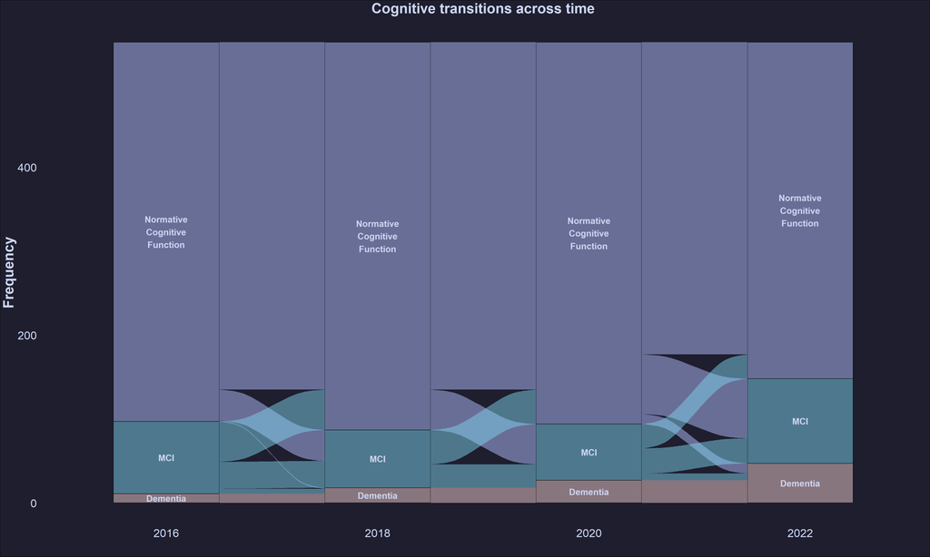

Figure 1: Cognitive transitions across time

## Data Analysis

### Modelling

```r
fit_a <- nnet::multinom(
  formula = status ~ Gender + Education_tri + Depression + (Age * Total_p) + status_prev,
  data = data_stack, family = multinomial, trace = FALSE)

fit_b <- nnet::multinom(
  formula = status ~ Gender + Education_tri + Depression + (Age * Total_p) + status_prev,
  data = data_stack |> mutate(status = relevel(status, ref = "2")),
  family = multinomial, trace = FALSE)

fit_results <- rbind(tidy_output(fit = fit_a), tidy_output(fit = fit_b))

fit_results |> head() |> output_model()
```

| transition | term | estimate | p.value | conf.low | conf.high |
| --- | --- | --- | --- | --- | --- |
| NC - MCI | Being female | 0.993 | 0.965 | 0.730 | 1.350 |
| NC - MCI | High school degree vs. No education | 0.465 | 0.000 | 0.376 | 0.575 |
| NC - MCI | Further education vs. No education | 0.318 | 0.000 | 0.272 | 0.373 |
| NC - MCI | Depression | 1.349 | 0.005 | 1.096 | 1.660 |
| NC - MCI | Age | 1.007 | 0.019 | 1.001 | 1.013 |
| NC - MCI | Procrastination (2020) | 0.921 | 0.000 | 0.882 | 0.962 |

## Data Analysis

### Odds Ratios

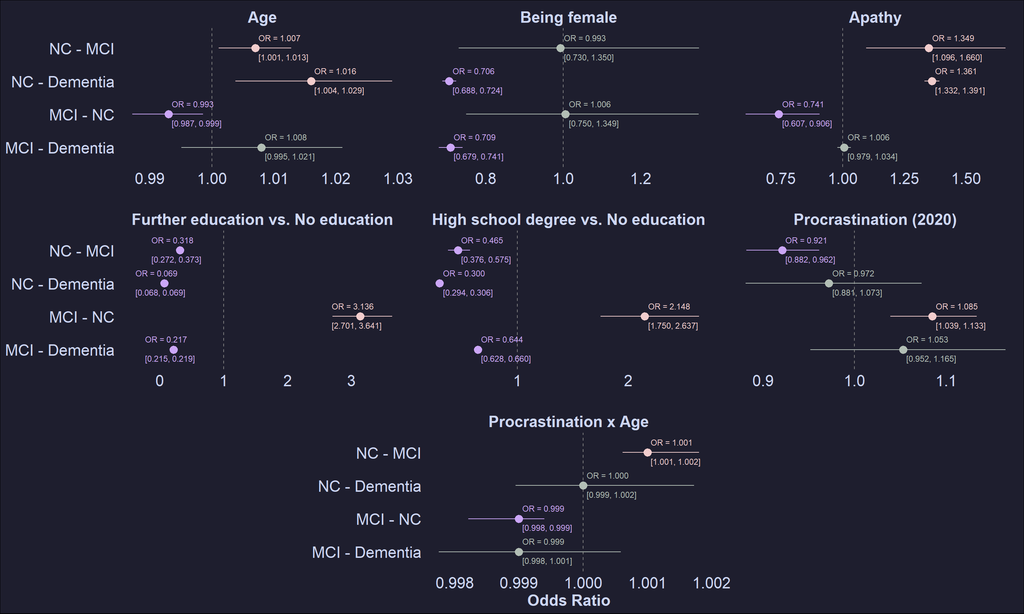

Figure 2: Odds ratios (95% Confidence Intervals) of transitioning from one cognitive state to another

## Data Analysis

### Predictions

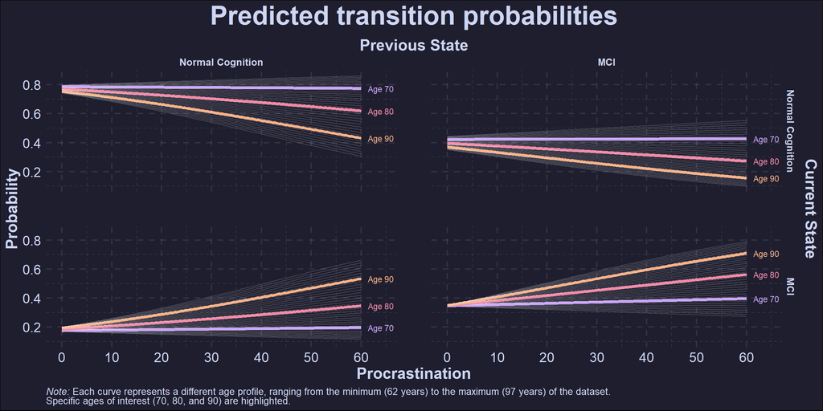

Figure 3: Predicted transition probabilities for different age cohorts

## Conclusions

- Preliminary evidence that procrastination may function as an early behavioural marker of cognitive decline, particularly in older age
- As a modifiable and measurable construct, procrastination holds promise as a target for early detection and preventative intervention

## References

1. Nichols, E., Steinmetz, J. D., Vollset, S. E., Fukutaki, K., Chalek, J., Abd-Allah, F., Abdoli, A., Abualhasan, A., Abu-Gharbieh, E., Akram, T. T., et al. (2022). Estimation of the global prevalence of dementia in 2019 and forecasted prevalence in 2050: An analysis for the global burden of disease study 2019. *The Lancet Public Health*, *7*(2), e105–e125. https://doi.org/10.1016/S2468-2667(21)00249-8

2. Cooper, C., Sommerlad, A., Lyketsos, C. G., & Livingston, G. (2015). Modifiable predictors of dementia in mild cognitive impairment: A systematic review and meta-analysis. *American Journal of Psychiatry*, *172*(4), 323–334. https://doi.org/10.1176/appi.ajp.2014.14070878

3. Shigemizu, D., Akiyama, S., Higaki, S., Sugimoto, T., Sakurai, T., Boroevich, K. A., Sharma, A., Tsunoda, T., Ochiya, T., Niida, S., & Ozaki, K. (2020). Prognosis prediction model for conversion from mild cognitive impairment to alzheimer’s disease created by integrative analysis of multi-omics data. *Alzheimer’s Research & Therapy*, *12*, 1–12. https://doi.org/10.1186/s13195-020-00716-0

4. Tschanz, J., Welsh-Bohmer, K., Lyketsos, C., Corcoran, C., Green, R. C., Hayden, K., Norton, M. C., Zandi, P., Toone, L., West, N., et al. (2006). Conversion to dementia from mild cognitive disorder: The cache county study. *Neurology*, *67*(2), 229–234. https://doi.org/10.1212/01.wnl.0000224748.48011.84

5. Dalen, J. W. van, Wanrooij, L. L. van, Charante, E. P. M. van, Brayne, C., Gool, W. A. van, & Richard, E. (2018). Association of apathy with risk of incident dementia: A systematic review and meta-analysis. *JAMA Psychiatry*, *75*(10), 1012–1021. https://doi.org/10.1001/jamapsychiatry.2018.1877

[figure not shown]